# Investigating Spatial Variation in Access to Healthcare Infrastructure Within Bristol

2106839

#### Word Count: 3495

## Introduction

Investigating spatial variation in healthcare accessibility is of critical importance, as it directly impacts health outcomes, can highlight geographic inequalities and help inform public health strategies. According to the World Health Organisation, every human being has the right to the highest attainable standard of mental and physical health and countries have a legal obligation to guarantee universal access to quality health services and address causes of health disparities (WHO, 2023). This project will therefore seek to investigate whether residents of Bristol, United Kingdom have equitable access to health infrastructure by using network analysis techniques to identify Local Super Output Level disparities in access to health services. In addition, disparities based on geographic location, socioeconomic characteristics and demographic factors will be explored to provide a comprehensive understanding of healthcare accessibility in the city.

## Literature Review

Health inequalities are “unfair and avoidable differences in health across the population and between different groups within society” (NHS, 2024) and healthcare inequalities focus on how healthcare services contribute to general health inequalities (Healthwatch, 2024).

In the UK the National Health Service (NHS) is funded through taxation to provide population-wide access to health services, irrespective of ability to pay (Cowling, 2014). Equitable access to healthcare has been a central objective of the NHS since its inception in 1948 (Goddard & Smith, 2001), however, literature shows that inequalities continue to prevail (Chouhan & Nazroo, 2020; Healthwatch, 2024). There is significant evidence of marginalised communities, particularly those with lower socioeconomic status accessing healthcare infrastructure less than others (Healtwatch, 2024). This idea is also seen in ethnic minority groups (Chouhan & Nazroo, 2020). These inequalities pose a significant threat to health equality in the UK, with the mortality rate in the lowest Index of Multiple Deprivation decile being almost double that of the highest (Mallorie, 2024). With poverty creating additional barriers to accessing healthcare services, equal proximity to GPs and hospitals should be prioritised as a baseline for ensuring equitable access to healthcare.

In Bristol in particular, there is evidence of individuals struggling to reach public healthcare services, due to lack of local provision and public transport cutbacks (Healthwatch, 2024). This report will therefore focus on what LSOAs these inequalities occur in and what communities they affect. In this analysis the nodes, represent LSOAs and GPs/hospitals, the edges represent the road connections between LSOAs and GPs/hospitals and the weights are the travel times by different methods of transport.

### Research Questions

**RQ1:** What are the spatial patterns of travel times from Lower Super Output Areas (LSOAs) in Bristol to the nearest GP surgery or hospital, and how do these vary across the city?

**RQ2:** How do demographic and socioeconomic factors influence accessibility to GPs and hospitals within Bristol?

## Methods

### Data Collection:

**Bristol Road Network:** The Bristol road network data, including walking, cycling, and driving paths, will be sourced from OpenStreetMap. This data will also be used to visualise the Bristol Road network.

**GP and Hospital Data:** The GP surgery and hospital data is taken from the NHS’s GP and GP practice-related data set. This data will be filtered for active GPs and hospitals that are within the bounds of Bristol LSOAs. GPs and hospitals have been chosen as the points of analysis as they are the only self-referral health infrastructure in the UK (Cowling, 2014). This data set does not contain geometry, so postcodes will be converted to coordinates.

**Bristol LSOAs:** Bristol LSOA data is taken from Open Data Bristol’s Lower Layer Super Output Areas 2021 (Precise) dataset. LSOAs were chosen as the unit of analysis because they provide a standardised unit for analysis that allows data integration from additional sources.

**Demographic and Socioeconomic Data:** Demographic and socioeconomic data including IMD, population, car availability and ethnicity will be taken from the Bristol Open Data Portal and ONS census data.

### Data Analysis:

**Centrality Measures:**

Centrality measures will be applied to analyse the structure and function of the healthcare network.

**Accessibility Measures:**

Accessibility will be assessed using:

- **Travel Time Analysis:**

Average travel times from LSOA centroids to the nearest GP/hospital will be calculated.

- **2-Step Floating Catchment Area (2SFCA) Method:**

Evaluating healthcare access by considering, supply (facilities within a travel time) and demand (population size).

**Cluster Analysis:**

K-means Clustering will be used to group LSOAs into clusters based on similarities in travel times and healthcare facility availability.

**Equity Assessment:**

Disparities in healthcare accessibility in different communities will be analysed by comparing travel times across LSOAs, with particular attention to IMD deprivation indices, ethnicity and car ownership.

**Statistical Analysis:**

Correlation and regression analysis will be conducted to examine the relationship between healthcare accessibility and demographic/socioeconomic variables.

### Downloading Necessary Packages

```r
library(osmdata)
library(sf)
library(tidyverse)
library(dplyr)
library(sfnetworks)
library(igraph)
library(tidygraph)
library(tidygeocoder)
library(osrm)
library(ggplot2)
library(accessibility)
library(dodgr)
library(patchwork)
library(magrittr)
library(spdep)
library(tmap)
library(cluster)
library(factoextra)
library(scales)
library(gridExtra)
library(knitr)
```

### Downloading Data

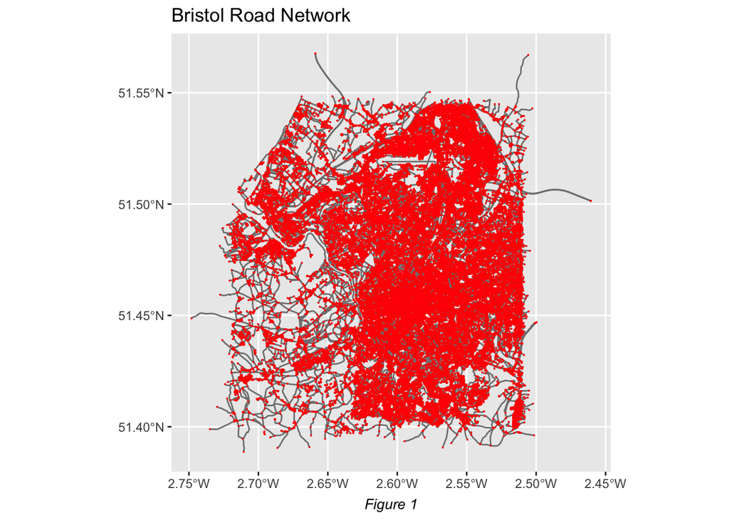

```r
#Bristol street network

#Extracting Bristol boundary from ONS

bristol_bbox = getbb("Bristol, UK")

# Bristol road network

bristol_street_data = opq(bbox = bristol_bbox) %>%
  add_osm_feature(key = 'highway') %>%
  osmdata_sf(quiet = FALSE)

bristol_roads = st_geometry(bristol_street_data$osm_lines)

bristol_network = as_sfnetwork(bristol_roads, directed = FALSE, length_as_weight = TRUE)

# Plotting the network we have created

ggplot() +
  geom_sf(data = st_as_sf(bristol_network, "edges"), col = "grey50") +
  geom_sf(data = st_as_sf(bristol_network, "nodes"), size = .001, col = "red")+
  ggtitle("Bristol Road Network")+
  labs(caption = "Figure 1")+
  theme(
    plot.caption = element_text(size = 10, face = "italic", hjust = 0.5)
  )
```

```r
# Reducing the size of the network by getting rid of repeated/overlapping nodes and edges, making sure to keep track of size of original network

gsize(bristol_network)  # number of edges
```

```
## [1] 48998
```

```r
gorder(bristol_network) # number of nodes
```

```
## [1] 72422
```

```r
bristol_wrangled = bristol_network %>%
  activate("edges") %>%
  filter(!edge_is_multiple()) %>%   # Simplify the network
  filter(!edge_is_loop())           # Simplify the network

bristol_wrangled = convert(bristol_wrangled, to_spatial_smooth)

# size of simplified network
gsize(bristol_wrangled)  # number of edges
```

```
## [1] 35923
```

```r
gorder(bristol_wrangled)  # number of nodes
```

```
## [1] 59653
```

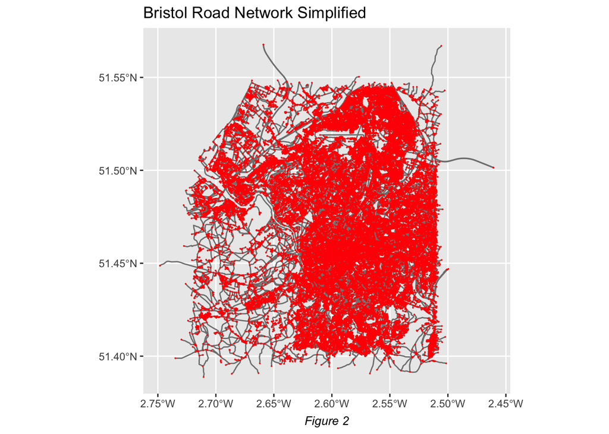

```r
# Plotting new simplified network

ggplot() +
  geom_sf(data = st_as_sf(bristol_wrangled, "edges"), col = "grey50") +
  geom_sf(data = st_as_sf(bristol_wrangled, "nodes"), size = .01, col = "red")+
  ggtitle("Bristol Road Network Simplified") +
  labs(caption = "Figure 2")+
  theme(
    plot.caption = element_text(size = 10, face = "italic", hjust = 0.5)
  )
```

```r
# Bristol LSOAs

lsoa_bristol = read_sf("Lower_Layer_Super_Output_Areas_2021_(Precise).shp")
```

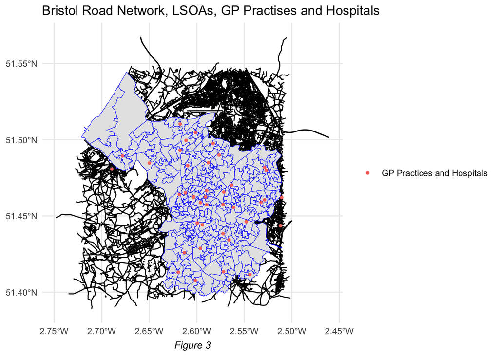

```r
# GP surgeries and hospitals

gp = read.csv("epraccur.csv")

# Filter for only active institutions

gp_active = gp %>%
  filter(gp[[13]] == "A")

# Filter for only GP surgeries and hospitals

gp_filtered = gp_active %>%
  filter(gp_active[[26]] == 4 | gp_active[[26]] == 10)

# Filter for GP surgeries and hospitals only in Bristol

gp_bristol = gp_filtered %>%
  filter(grepl("BRISTOL", gp_filtered[[6]]) |
         grepl("BRISTOL", gp_filtered[[7]]) |
         grepl("BRISTOL", gp_filtered[[8]]))

# Manually filter rows that are not in Bristol - long-winded way of removing practices that are either outside of or out of reach of the Bristol LSOAs

gp_bristol = gp_bristol %>%
  slice(-c(1,7,10,11,14,15,16,17,20,24,25,26,27,28,32,35,37,38,48,55,56,57,58,61,62,65,66,67,68,69,71,72,73,74,76,78,79 ))

# Get rid of unnecessary columns for ease

gp_bristol = gp_bristol %>%
  select(-c(3, 4, 9, 11, 12, 14, 15, 16, 17, 18, 19, 20, 21, 22, 23, 24, 25, 27))

# Rename columns

colnames(gp_bristol) = c("Org code", "Name", "Adress1", "Adress2", "Adress3", "Adress4", "Postcode", "Status", "Setting")

# Covert postcodes to coordinates and add this in a new column

gp_bristol = gp_bristol %>%
  geocode(Postcode, method = "osm", lat = latitude, long = longitude)

# Covert to geometry

gp_bristol = st_as_sf(gp_bristol, coords = c("longitude", "latitude"), crs = 4326)

# Plot GP and hospitals

ggplot() +
  geom_sf(data = st_geometry(bristol_wrangled), color = "black") +
  geom_sf(data = lsoa_bristol, col="blue") +
  geom_sf(data = gp_bristol, aes(color = "GP Practices and Hospitals"), size = 1) +
  theme_minimal()+
  labs(color = NULL)+
  ggtitle("Bristol Road Network, LSOAs, GP Practises and Hospitals")+
  labs(caption = "Figure 3")+
  theme(
    plot.caption = element_text(size = 10, face = "italic", hjust = 0.5)
  )
```

Figure 3 shows Bristol’s LSOAs, road network, GP practices and hospitals, this is the spatial network this project will use for analysis.

## Centrality Measures

```r
# Creating a network which includes road networks, GP's and Hospital centroids and LSOA centroids

lsoa_centres = st_centroid(lsoa_bristol)

gp_bristol_centres = st_centroid(gp_bristol)

# Extract road geometries

bristol_roads = bristol_street_data$osm_lines

# Change to same CRS

bristol_roads = st_transform(bristol_roads, crs = 27700)

gp_bristol_centres = st_transform(gp_bristol_centres, crs = st_crs(bristol_roads))

lsoa_centres = st_transform(lsoa_centres, crs = st_crs(bristol_roads))

# Snap GPS points and LSOAs to the nearest road node

gp_snapped = st_nearest_feature(gp_bristol_centres, bristol_roads)
lsoa_snapped = st_nearest_feature(lsoa_centres, bristol_roads)

# Create an edge list for the road network

edges = st_coordinates(bristol_roads) %>%
  as.data.frame() %>%
  group_by(L1) %>%
  summarise(
    from_lon = first(X), from_lat = first(Y),
    to_lon = last(X), to_lat = last(Y)
  ) %>%
  ungroup()

# Create a node list with unique identifiers

nodes = edges %>%
  select(from_lon, from_lat) %>%
  rename(lon = from_lon, lat = from_lat) %>%
  bind_rows(
    edges %>%
      select(to_lon, to_lat) %>%
      rename(lon = to_lon, lat = to_lat)
  ) %>%
  distinct() %>%
  mutate(node_id = row_number())

# Replace coordinates in edges with node IDs

edges = edges %>%
  left_join(nodes, by = c("from_lon" = "lon", "from_lat" = "lat")) %>%
  rename(from = node_id) %>%
  left_join(nodes, by = c("to_lon" = "lon", "to_lat" = "lat")) %>%
  rename(to = node_id) %>%
  mutate(weight = sqrt((to_lon - from_lon)^2 + (to_lat - from_lat)^2)) %>%  # Weight by distance
  select(from, to, weight)

# Create the graph

graph = graph_from_data_frame(edges, directed = FALSE)

# Assign weights to edges

E(graph)$weight = edges$weight

# Map GPS and LSOA snapped indices to node IDs

gps_node_ids = gp_snapped
lsoa_node_ids = lsoa_snapped

# Add metadata for key nodes

nodes = nodes %>%
  mutate(
    type = case_when(
      node_id %in% gps_node_ids ~ "GP",
      node_id %in% lsoa_node_ids ~ "LSOA",
      TRUE ~ "Road"
    )
  )

# Work out centrality measures

degree_centrality = degree(graph, mode = "all")
nodes = nodes %>%
  mutate(degree = degree_centrality[node_id])

betweenness_centrality = betweenness(graph, weights = E(graph)$weight, normalized = TRUE)
nodes = nodes %>%
  mutate(betweenness = betweenness_centrality[node_id])

closeness_centrality = closeness(graph, weights = E(graph)$weight, normalized = TRUE)
nodes = nodes %>%
  mutate(closeness = closeness_centrality[node_id])

# Filter for nodes of interest

key_nodes = nodes %>%
  filter(type %in% c("GP", "LSOA"))
```

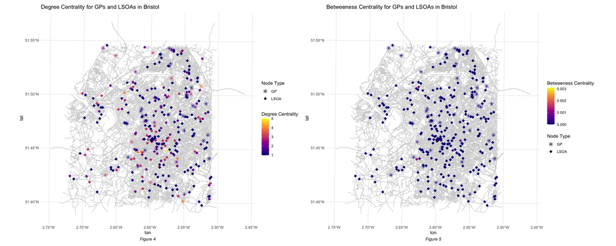

```r
# Plotting degree centrality

degree_plot =ggplot() +
  geom_sf(data = bristol_roads, color = "lightgrey") +
  geom_point(
    data = key_nodes,
    aes(x = lon, y = lat, color = degree, shape = type),
    size = 3
  ) +
  scale_color_viridis_c(option = "plasma") +
  scale_shape_manual(
    values = c("GP" = 8, "LSOA" = 18),
    name = "Node Type"
  ) +
  labs(
    title = "Degree Centrality for GPs and LSOAs in Bristol",
    color = "Degree Centrality",
    caption = "Figure 4"
  ) +
  theme_minimal()+
  theme(
    plot.caption = element_text(size = 10, face = "italic", hjust = 0.5)
  )

# Plotting betweeness centrality

betweeness_plot = ggplot() +
  geom_sf(data = bristol_roads, color = "lightgrey") +
  geom_point(
    data = key_nodes,
    aes(x = lon, y = lat, color = betweenness, shape = type),
    size = 3
  ) +
  scale_color_viridis_c(option = "plasma") +
  scale_shape_manual(
    values = c("GP" = 8, "LSOA" = 18),
    name = "Node Type"
  ) +
  labs(
    title = "Betweeness Centrality for GPs and LSOAs in Bristol",
    color = "Betweeness Centrality",
    caption = "Figure 5"
  ) +
  theme_minimal()+
  theme(
    plot.caption = element_text(size = 10, face = "italic", hjust = 0.5)
  )


# Plotting closeness centrality

closeness_plot = ggplot() +
  geom_sf(data = bristol_roads, color = "lightgrey") +
  geom_point(
    data = key_nodes,
    aes(x = lon, y = lat, color = closeness, shape = type),
    size = 3
  ) +
  scale_color_viridis_c(option = "plasma") +
  scale_shape_manual(
    values = c("GP" = 8, "LSOA" = 18),
    name = "Node Type"
  ) +
  labs(
    title = "Closeness Centrality for GPs and LSOAs in Bristol",
    color = "Closeness Centrality",
    caption = "Figure 6"
  ) +
  theme_minimal()+
  theme(
    plot.caption = element_text(size = 10, face = "italic", hjust = 0.5)
  )


degree_plot + betweeness_plot
```

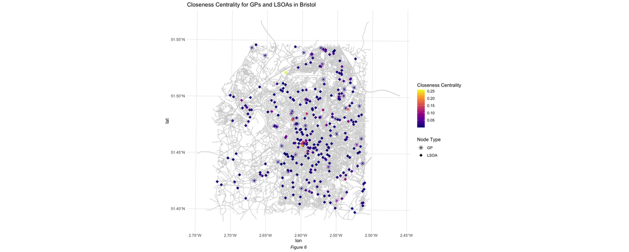

```r
closeness_plot
```

**Degree Centrality**

Degree centrality measures the number of connections (edges) a node has (Golbeck, 2015). Here the degree centrality plot for GPs, hospitals and LSOAs shows how many direct connections the point of interest has within the network.

GPs/hospitals in central Bristol generally have a lower degree centrality compared to peripheral GPs/hospitals. This is likely due to central Bristol’s dense, interconnected urban structure distributing connections across multiple GPs/hospitals, rather than concentrating them. In this case, a lower degree centrality indicates a well-integrated urban healthcare network, rather than poor accessibility. A generally higher degree centrality is seen in peripheral areas, most likely due to fewer GPs/hospitals and a sparser road network, increasing direct connections to a single GP/hospital.

For LSOA centroids, the trend reverses, with a higher degree centrality in central Bristol compared to peripheral areas. This is likely due to a higher density of road nodes and GPs/hospitals in the urban centre of Bristol, meaning LSOA centroids have more direct connections. Here, a lower degree centrality in more peripheral areas may indicate issues in healthcare access.

**Betweenness Centrality**

Betweenness centrality measures how often a node lies on the shortest path between all pairs of nodes in a network (Wasserman & Faust, 1994). The general low betweenness centrality seen for both LSOAs would be expected here as there are likely alternative routes or connections within the network that bypass these specific nodes. As a result, there is little spatial variation in accessibility across the network as no GP/hospital or LSOA node facilitates connectivity between other parts of the network.

**Closeness Centrality**

Closeness centrality shows the closeness of a node to all other nodes in the network, it is calculated as the average of the shortest path length from the node to every other node in the network (Goldbeck, 2013). LSOA and GP nodes with higher closeness centrality cluster near the centre of Bristol, suggesting better connectivity and more efficient service. LSOAs and GPs in the peripheral areas of Bristol have lower closeness centrality, suggesting lower accessibility and a longer average distance to other nodes. This suggests that access to GPs/hospitals is uneven, with residents in peripheral areas likely experiencing longer travel time.

## Calculating Time Taken to Reach the Nearest GP or Hospital from Each LSOA Centroid

```r
# Fixing invalid geometries and prepare data

invalid_geometries = lsoa_bristol[!st_is_valid(lsoa_bristol), ]

# Displaying invalid geometries
print(invalid_geometries)
```

```
## Simple feature collection with 1 feature and 7 fields
## Geometry type: MULTIPOLYGON
## Dimension:     XY
## Bounding box:  xmin: 363350.4 ymin: 173777.2 xmax: 364229.7 ymax: 174356.3
## Projected CRS: OSGB36 / British National Grid
## # A tibble: 1 × 8
##   OBJECTID LSOA21CD  LSOA21NM     LSOA21LN        Note  ShapeSTAre ShapeSTLen
##      <int> <chr>     <chr>        <chr>           <chr>      <dbl>      <dbl>
## 1        1 E01014674 Bristol 027B Burchells Green <NA>     228210.      3550.
## # ℹ 1 more variable: geometry <MULTIPOLYGON [m]>
```

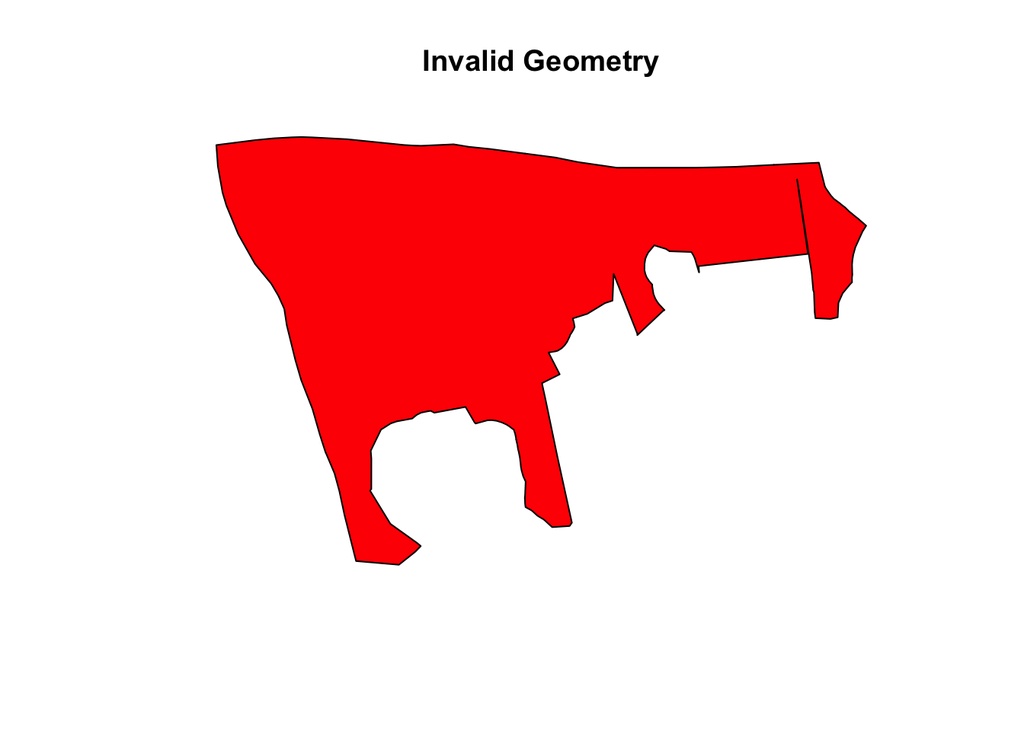

```r
# Plotting the invalid geometry
plot(st_geometry(invalid_geometries), col = "red", main = "Invalid Geometry")
```

```r
# Fix geometry
fixed_geometry = st_make_valid(invalid_geometries)

# Replacing the invalid geometry in the dataset
lsoa_bristol[!st_is_valid(lsoa_bristol), ] = fixed_geometry

# Convert to centroids

lsoa_centres = st_centroid(lsoa_bristol)

gp_bristol_centres = st_centroid(gp_bristol)
```

```r
# Calculate driving times

# Splitting the data set in half due to OSRM limitations and computing travel time matrix

dist_car_1= osrmTable(
  src = lsoa_centres[1:134, ],
  dst = gp_bristol_centres[],
  measure = "duration",
  osrm.profile = "car"
)

dist_car_2= osrmTable(
  src = lsoa_centres[135:268, ],
  dst = gp_bristol_centres[],
  measure = "duration",
  osrm.profile = "car"
)

# Extract travel duration matrices

help_1 = dist_car_1$durations

help_2 = dist_car_2$durations

# Assign row and column names

rownames(help_1) = as.vector(lsoa_centres$LSOA21CD[1:134])

rownames(help_2) = as.vector(lsoa_centres$LSOA21CD[135:268])

colnames(help_1) = as.vector(gp_bristol_centres$Name[])

colnames(help_2) = as.vector(gp_bristol_centres$Name[])

# Convert travel matrices to dataframes

dist_car.df_1 = as.data.frame(as.table(help_1)) %>%
  rename(from_id = Var1,
         to_id = Var2,
         travel_time = Freq)

dist_car.df_2 = as.data.frame(as.table(help_2)) %>%
  rename(from_id = Var1,
         to_id = Var2,
         travel_time = Freq)

# Combine dataframes

dist_car = rbind(dist_car.df_1, dist_car.df_2)
```

```r
# Calculate minimum time to reach a GP by car

lsoa_with_time = lsoa_bristol %>%
  left_join(dist_car, by = c("LSOA21CD" = "from_id"))

lsoa_with_time = lsoa_with_time %>%
  group_by(LSOA21LN) %>%
  summarize(min_travel_time = min(travel_time, na.rm = TRUE))

# Calculate min and max

summary(lsoa_with_time$min_travel_time)
```

```
##    Min. 1st Qu.  Median    Mean 3rd Qu.    Max.
##   0.100   1.800   2.700   2.818   3.525   8.900
```

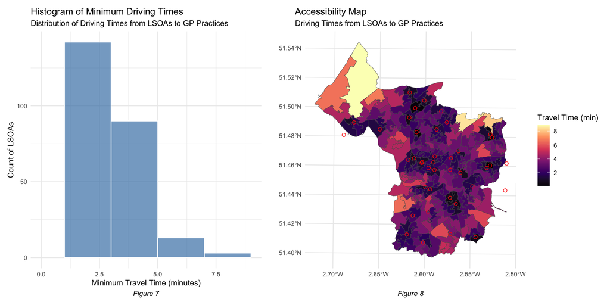

```r
# Plot minimum driving time

plot1 = ggplot() +
  geom_sf(data = lsoa_with_time, aes(fill = min_travel_time)) +
  geom_sf(data = gp_bristol, color = "red", size = 2, shape = 21) +
  scale_fill_viridis_c(option = "magma", name = "Travel Time (min)") +
  labs(
    title = "Accessibility Map",
    subtitle = "Driving Times from LSOAs to GP Practices",
    caption = "Figure 8"
  ) +
  theme_minimal()+
  theme(
    plot.caption = element_text(size = 10, face = "italic", hjust = 0.5)
  )

# Histogram of driving times

plot2 = ggplot(data = lsoa_with_time, aes(x = min_travel_time)) +
  geom_histogram(binwidth = 2, fill = "steelblue", color = "white", alpha = 0.7) +
  scale_x_continuous(name = "Minimum Travel Time (minutes)", limits = c(0, NA)) +
  scale_y_continuous(name = "Count of LSOAs") +
  labs(
    title = "Histogram of Minimum Driving Times",
    subtitle = "Distribution of Driving Times from LSOAs to GP Practices",
    caption = "Figure 7"
  ) +
  theme_minimal()+
  theme(
    plot.caption = element_text(size = 10, face = "italic", hjust = 0.5)
  )

combined_plot = plot2 + plot1 +
  plot_layout(ncol = 2, widths = c(1, 1))

combined_plot
```

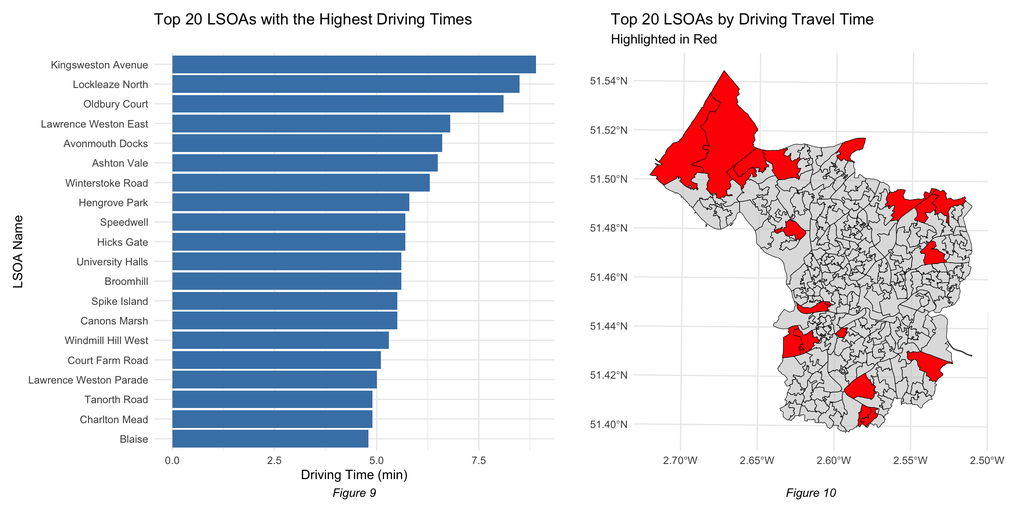

```r
# Create a bar chart of top 20 LSOAs with highest driving times

top_20_lsoas_car = lsoa_with_time %>%
  arrange(desc(min_travel_time)) %>%
  slice(1:20)

plot1 = ggplot(data = top_20_lsoas_car, aes(x = reorder(LSOA21LN, min_travel_time), y = min_travel_time)) +
  geom_bar(stat = "identity", fill = "steelblue") +
  coord_flip() +
  labs(
    title = "Top 20 LSOAs with the Highest Driving Times",
    x = "LSOA Name",
    y = "Driving Time (min)",
    caption = "Figure 9"
  ) +
  theme_minimal()+
  theme(
    plot.caption = element_text(size = 10, face = "italic", hjust = 0.5)
  )


# Plotting the LSOAs

plot_car = ggplot() +
  geom_sf(data = lsoa_with_time, fill = "gray", color = "black", alpha = 0.5) + # All LSOAs in gray
  geom_sf(data = top_20_lsoas_car, fill = "red", color = "black", size = 0.7) + # Top 20 LSOAs in red
  theme_minimal() +
  labs(
    title = "Top 20 LSOAs by Driving Travel Time",
    subtitle = "Highlighted in Red",
    caption = "Figure 10"
  )+
  theme(
    plot.caption = element_text(size = 10, face = "italic", hjust = 0.5)
  )


combined_plot = plot1 + plot_car +
  plot_layout(ncol = 2, widths = c(1, 1))

combined_plot
```

Figures 9 and 10 highlight the specific LSOAs with the highest driving times to the closest GP/hospital. Figure 10 highlights hotspots in the northwest and northeast, and identifies additional small clusters in the outskirts of the south of the city.

```r
# Calculate walking distance

#Splitting the data set in half due to OSRM limitations and computing travel time matrix
dist_walk_1= osrmTable(
  src = lsoa_centres[1:134, ],
  dst = gp_bristol_centres[],
  measure = "duration",
  osrm.profile = "foot"
)

dist_walk_2= osrmTable(
  src = lsoa_centres[135:268, ],
  dst = gp_bristol_centres[],
  measure = "duration",
  osrm.profile = "foot"
)

# Extract travel duration matrices

help_walk_1 = dist_walk_1$durations

help_walk_2 = dist_walk_2$durations

# Assign row and column names

rownames(help_walk_1) = as.vector(lsoa_centres$LSOA21CD[1:134])

rownames(help_walk_2) = as.vector(lsoa_centres$LSOA21CD[135:268])

colnames(help_walk_1) = as.vector(gp_bristol_centres$Name[])

colnames(help_walk_2) = as.vector(gp_bristol_centres$Name[])

# Convert travel matrices to dataframes

dist_walk.df_1 = as.data.frame(as.table(help_walk_1)) %>%
  rename(from_id = Var1,
         to_id = Var2,
         travel_time = Freq)

dist_walk.df_2 = as.data.frame(as.table(help_walk_2)) %>%
  rename(from_id = Var1,
         to_id = Var2,
         travel_time = Freq)

# Combine dataframes

dist_walk = rbind(dist_walk.df_1, dist_walk.df_2)
```

```r
# Calculate minimum time to reach a GP by foot

lsoa_with_time_walk = lsoa_bristol %>%
  left_join(dist_walk, by = c("LSOA21CD" = "from_id"))

lsoa_with_time_walk = lsoa_with_time_walk  %>%
  group_by(LSOA21LN) %>%
  summarize(min_travel_time = min(travel_time, na.rm = TRUE))

# Work out min and max

summary(lsoa_with_time_walk$min_travel_time)
```

```
##    Min. 1st Qu.  Median    Mean 3rd Qu.    Max.
##   0.600   8.475  12.500  13.730  16.600  62.300
```

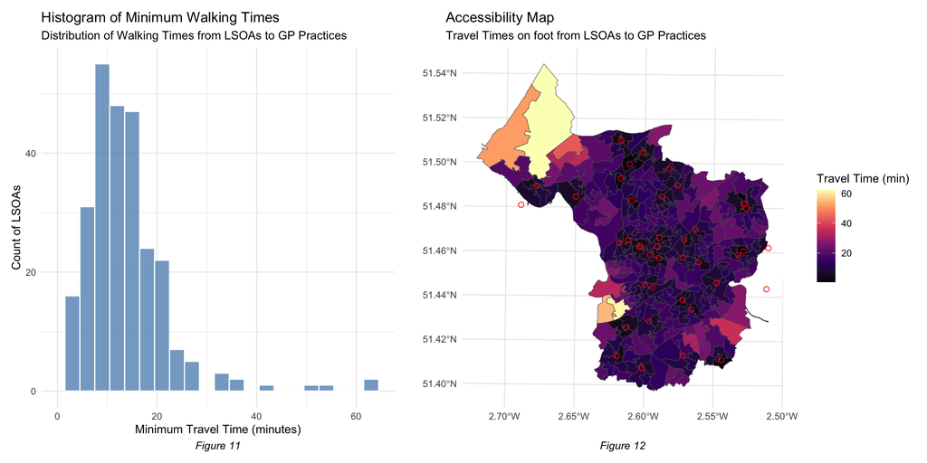

```r
# Plot minimum driving time

plot1 = ggplot() +
  geom_sf(data = lsoa_with_time_walk, aes(fill = min_travel_time)) +
  geom_sf(data = gp_bristol, color = "red", size = 2, shape = 21) +
  scale_fill_viridis_c(option = "magma", name = "Travel Time (min)") +
  labs(
    title = "Accessibility Map",
    subtitle = "Travel Times on foot from LSOAs to GP Practices",
    caption = "Figure 12"
  ) +
  theme_minimal()+
  theme(
    plot.caption = element_text(size = 10, face = "italic", hjust = 0.5)
  )


# Histogram of walking times

plot2 = ggplot(data = lsoa_with_time_walk, aes(x = min_travel_time)) +
  geom_histogram(binwidth = 3, fill = "steelblue", color = "white", alpha = 0.7) +
  scale_x_continuous(name = "Minimum Travel Time (minutes)",limits = c(0, NA)) +
  scale_y_continuous(name = "Count of LSOAs") +
  labs(
    title = "Histogram of Minimum Walking Times",
    subtitle = "Distribution of Walking Times from LSOAs to GP Practices",
    caption = "Figure 11"
  ) +
  theme_minimal()+
  theme(
    plot.caption = element_text(size = 10, face = "italic", hjust = 0.5)
  )

combined_plot = plot2 + plot1 +
  plot_layout(ncol = 2, widths = c(1, 1))

combined_plot
```

Figure 11 shows that minimum walking times from LSOA centroids to GPs/hospitals vary more significantly, ranging from less than a minute to over an hour. The median walking time is 12.5 minutes indicating relatively well-located GPs and hospitals. The large variation, however, implies inequalities in access. Figure 12 shows a similar spatial pattern to that of driving times, with the centre of Bristol exhibiting the lowest walking times and more periphery areas, particularly in the northwest and southwest exhibiting the highest.

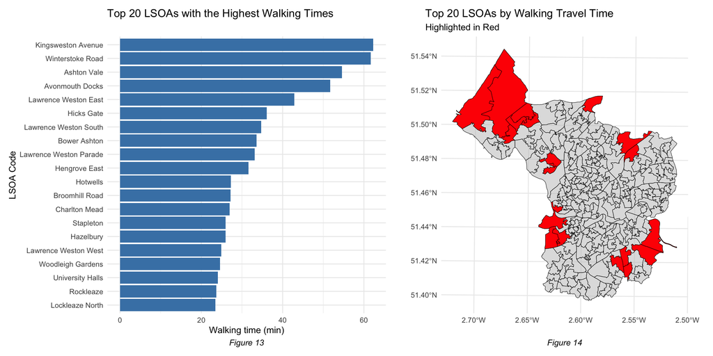

```r
# Create a bar chart of top 20 LSOAs with highest walking times

top_20_lsoas_walk = lsoa_with_time_walk %>%
  arrange(desc(min_travel_time)) %>%
  slice(1:20)

plot2 = ggplot(data = top_20_lsoas_walk, aes(x = reorder(LSOA21LN, min_travel_time), y = min_travel_time)) +
  geom_bar(stat = "identity", fill = "steelblue") +
  coord_flip() +
  labs(
    title = "Top 20 LSOAs with the Highest Walking Times",
    x = "LSOA Code",
    y = "Walking time (min)",
    caption = "Figure 13"
  ) +
  theme_minimal()+
  theme(
    plot.caption = element_text(size = 10, face = "italic", hjust = 0.5)
  )

plot_walk = ggplot() +
  geom_sf(data = lsoa_with_time_walk, fill = "gray", color = "black", alpha = 0.5) + # All LSOAs in gray
  geom_sf(data = top_20_lsoas_walk, fill = "red", color = "black", size = 0.7) + # Top 20 LSOAs in red
  theme_minimal() +
  labs(
    title = "Top 20 LSOAs by Walking Travel Time",
    subtitle = "Highlighted in Red",
    caption = "Figure 14"
  )+
  theme(
    plot.caption = element_text(size = 10, face = "italic", hjust = 0.5)
  )

combined_plot = plot2 + plot_walk +
  plot_layout(ncol = 2, widths = c(1, 1))

combined_plot
```

Figures 13 and 14 show the top 20 LSOAs with the longest walking times. Again, the spatial pattern is similar to that of driving times, with periphery areas exhibiting the most significant walking times and several LSOAs being in the top 20 times for both driving and walking. However, walking times in the south of Bristol are lower.

```r
# Calculate cycling distance

# Splitting the data set in half due to OSRM limitations and computing travel time matrix

dist_bike_1= osrmTable(
  src = lsoa_centres[1:134, ],
  dst = gp_bristol_centres[],
  measure = "duration",
  osrm.profile = "bike"
)

dist_bike_2= osrmTable(
  src = lsoa_centres[135:268, ],
  dst = gp_bristol_centres[],
  measure = "duration",
  osrm.profile = "bike"
)

# Extract travel duration matrices

help_bike_1 = dist_bike_1$durations

help_bike_2 = dist_bike_2$durations

# Assign row and column names

rownames(help_bike_1) = as.vector(lsoa_centres$LSOA21CD[1:134])

rownames(help_bike_2) = as.vector(lsoa_centres$LSOA21CD[135:268])

colnames(help_bike_1) = as.vector(gp_bristol_centres$Name[])

colnames(help_bike_2) = as.vector(gp_bristol_centres$Name[])

# Convert travel matrices to dataframes

dist_bike.df_1 = as.data.frame(as.table(help_bike_1)) %>%
  rename(from_id = Var1,
         to_id = Var2,
         travel_time = Freq)

dist_bike.df_2 = as.data.frame(as.table(help_bike_2)) %>%
  rename(from_id = Var1,
         to_id = Var2,
         travel_time = Freq)

# Combine dataframes

dist_bike = rbind(dist_bike.df_1, dist_bike.df_2)
```

```r
# Calculate minimum time to reach a GP by bike

lsoa_with_time_bike = lsoa_bristol %>%
  left_join(dist_bike, by = c("LSOA21CD" = "from_id"))

lsoa_with_time_bike = lsoa_with_time_bike  %>%
  group_by(LSOA21LN) %>%
  summarize(min_travel_time = min(travel_time, na.rm = TRUE))

# max and min

summary(lsoa_with_time_bike$min_travel_time)
```

```
##    Min. 1st Qu.  Median    Mean 3rd Qu.    Max.
##   0.200   3.400   4.850   5.263   6.425  21.000
```

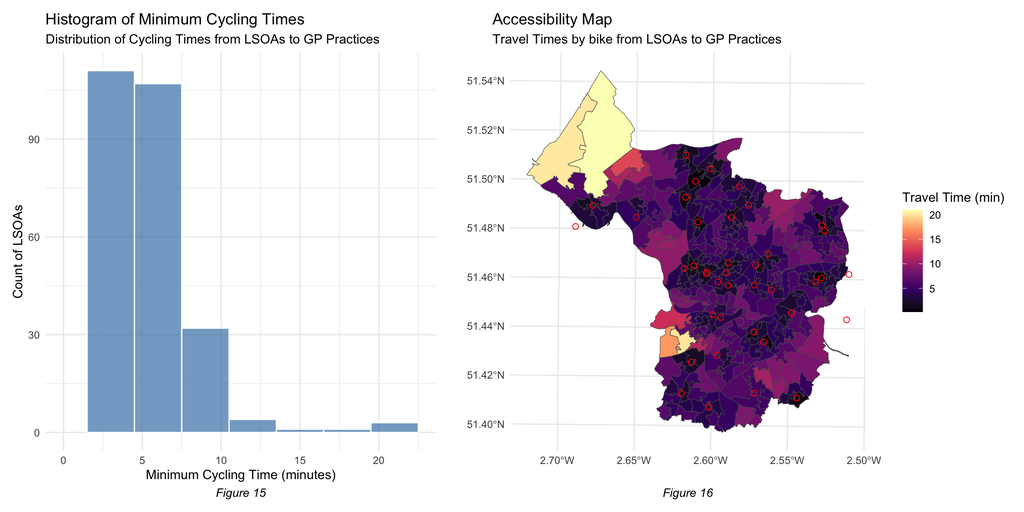

```r
# Plot minimum cycling time

plot1 = ggplot() +
  geom_sf(data = lsoa_with_time_bike, aes(fill = min_travel_time)) +
  geom_sf(data = gp_bristol, color = "red", size = 2, shape = 21) +
  scale_fill_viridis_c(option = "magma", name = "Travel Time (min)") +
  labs(
    title = "Accessibility Map",
    subtitle = "Travel Times by bike from LSOAs to GP Practices",
    caption = "Figure 16"
  ) +
  theme_minimal()+
  theme(
    plot.caption = element_text(size = 10, face = "italic", hjust = 0.5)
  )

plot2 = ggplot(data = lsoa_with_time_bike, aes(x = min_travel_time)) +
  geom_histogram(binwidth = 3, fill = "steelblue", color = "white", alpha = 0.7) +
  scale_x_continuous(name = "Minimum Cycling Time (minutes)", limits = c(0, NA)) +
  scale_y_continuous(name = "Count of LSOAs") +
  labs(
    title = "Histogram of Minimum Cycling Times",
    subtitle = "Distribution of Cycling Times from LSOAs to GP Practices",
    caption = "Figure 15"
  ) +
  theme_minimal()+
  theme(
    plot.caption = element_text(size = 10, face = "italic", hjust = 0.5)
  )

combined_plot = plot2 + plot1 +
  plot_layout(ncol = 2, widths = c(1, 1))

combined_plot
```

Figure 15 shows that GPs and hospitals are relatively accessible by bike with the majority of travel times under 10 minutes. Travel times range from under a minute to 21 minutes and the median is 4.85. Again, these are relatively moderate times, with a low median, however, the variation highlights significant inequality in access to healthcare. Figure 16 shows the same pattern as driving and walking, with peripheral areas having longer cycling times than areas closest to the centre, with the same hotspots in the northwest and southwest as walking.

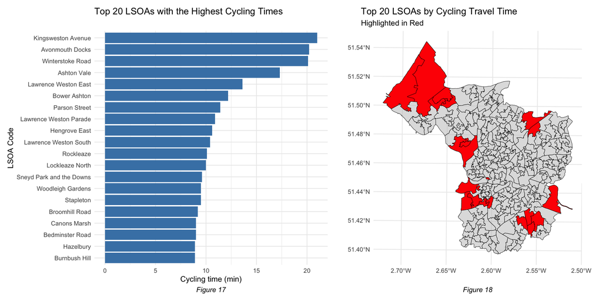

```r
# Create a bar chart of top 20 LSOAs with highest cycling times

top_20_lsoas_bike = lsoa_with_time_bike %>%
  arrange(desc(min_travel_time)) %>%
  slice(1:20)

plot1 = ggplot(data = top_20_lsoas_bike, aes(x = reorder(LSOA21LN, min_travel_time), y = min_travel_time)) +
  geom_bar(stat = "identity", fill = "steelblue") +
  coord_flip() +
  labs(
    title = "Top 20 LSOAs with the Highest Cycling Times",
    x = "LSOA Code",
    y = "Cycling time (min)",
    caption = "Figure 17"
  ) +
  theme_minimal()+
  theme(
    plot.caption = element_text(size = 10, face = "italic", hjust = 0.5)
  )

plot2 = ggplot() +
  geom_sf(data = lsoa_with_time_bike, fill = "gray", color = "black", alpha = 0.5) + # All LSOAs in gray
  geom_sf(data = top_20_lsoas_bike, fill = "red", color = "black", size = 0.7) + # Top 20 LSOAs in red
  theme_minimal() +
  labs(
    title = "Top 20 LSOAs by Cycling Travel Time",
    subtitle = "Highlighted in Red",
    caption = "Figure 18"
  )+
  theme(
    plot.caption = element_text(size = 10, face = "italic", hjust = 0.5)
  )

combined_plot = plot1 + plot2 +
  plot_layout(ncol = 2, widths = c(1, 1))

combined_plot
```

Figures 17 and 18 show the top 20 LSOAs with the longest cycling times to the nearest GP/hospital. The spatial pattern is again similar to both driving and walking, with the majority of LSOAs on the outskirts of Bristol. Similar to walking the most southerly areas of the city do not exhibit high cycling times in contrast to driving times.

## 2-Step Floating Catchment Area (2SFCA) Method

The 2-step floating catchment area method (2SFCA) is used to compare the number of facilities that are accessible to residents within a given threshold by setting a critical value of travel distance (Liu et al, 2022). In this research, population is incorporated to account for demand.

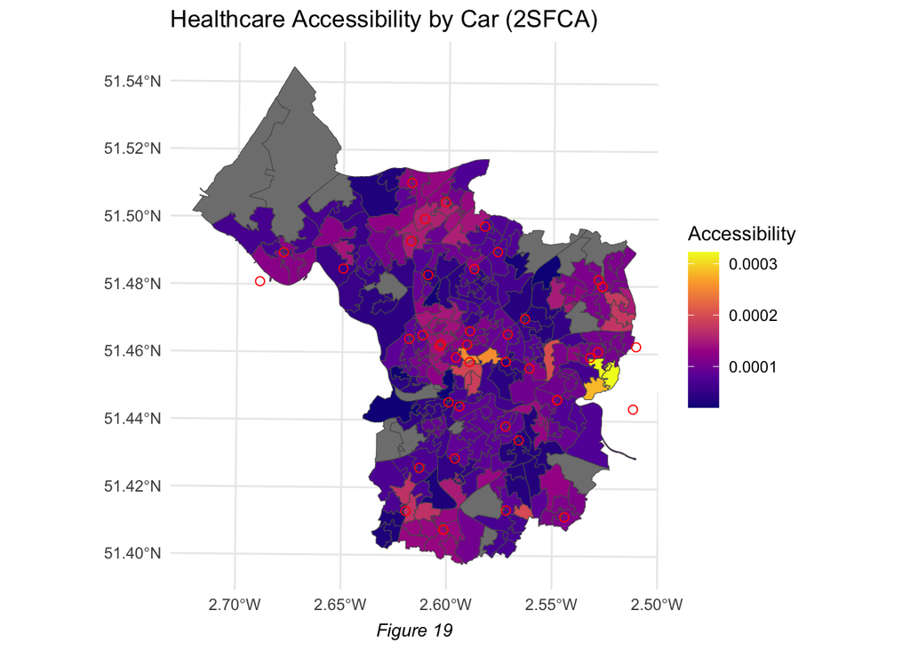

```r
# 2SFCA for driving

# Add population to data

population = read.csv("population.csv")

lsoa_population = merge(lsoa_bristol, population, by.x = "LSOA21CD", by.y = "LSOA.2021.Code")

lsoa_population = lsoa_population %>%
  mutate(Total = gsub(",", "", Total)) %>%
  mutate(Total = as.numeric(Total)) %>%
  mutate(Total = ifelse(is.na(Total), 0, Total))

# Set threshold

threshold = 5 #5 minutes

# Calculate GP-to-population ratios

gp_ratios = dist_car %>%
  filter(travel_time <= threshold) %>%  # Filter by threshold
  left_join(lsoa_population, by = c("from_id" = "LSOA21CD")) %>%  # Join population data
  group_by(to_id) %>%  # Group by GP ID
  summarise(
    catchment_population = sum(Total, na.rm = TRUE),  # Sum population in catchment
    ratio = ifelse(catchment_population == 0, 0, 1 / catchment_population)  # Calculate ratio
  )

# Calculate accessibility for each LSOA

lsoa_accessibility = dist_car %>%
  filter(travel_time <= threshold) %>%  # Filter by threshold
  left_join(gp_ratios, by = "to_id") %>%  # Join GP ratios
  group_by(from_id) %>%  # Group by LSOA ID
  summarise(
    accessibility = sum(ratio, na.rm = TRUE)  # Sum ratios for each LSOA
  ) %>%
  mutate(accessibility = ifelse(is.na(accessibility), 0, accessibility))  # Replace NA with 0

# Join accessibility scores with LSOA data

lsoa_population = lsoa_population %>%
  left_join(lsoa_accessibility, by = c("LSOA21CD" = "from_id"))

# Plot results

ggplot(lsoa_population) +
  geom_sf(aes(fill = accessibility)) +
    geom_sf(data = gp_bristol, color = "red", size = 2, shape = 21) +
  scale_fill_viridis_c(
    option = "plasma",
    labels = label_number(accuracy = 0.0001)  # Adjust to show 4 decimal places
  ) +
  theme_minimal() +
  labs(title = "Healthcare Accessibility by Car (2SFCA)",
       fill = "Accessibility",
       caption = "Figure 19")+
  theme(
    plot.caption = element_text(size = 10, face = "italic", hjust = 0.5)
  )
```

Figure 19 shows 2SFCA scores for accessibility of GPs/hospitals within a 5-minute driving distance from each LSOA centroid, accounting for population demand. Higher scores, highlighted in yellow and orange indicate better accessibility, lower scores highlighted in blue and purple reflect poorer accessibility and grey indicates areas are unreachable within 5 minutes of driving from any GP.

The highest scores are seen in east Bristol, likely due to a combination of low population demand and sufficient healthcare provision. More central areas of the city have slightly lower, but still relatively high accessibility scores, showing a reasonable balance between service availability and population demand. Several LSOAs on the outskirts of Bristol, primarily in the north and west, show the lowest levels of accessibility, indicating either low healthcare provision, high population demand or a combination of both. There are several clusters of low accessibility, even in close proximity to GPs/hospitals, indicating high population demand and therefore reduced accessibility.

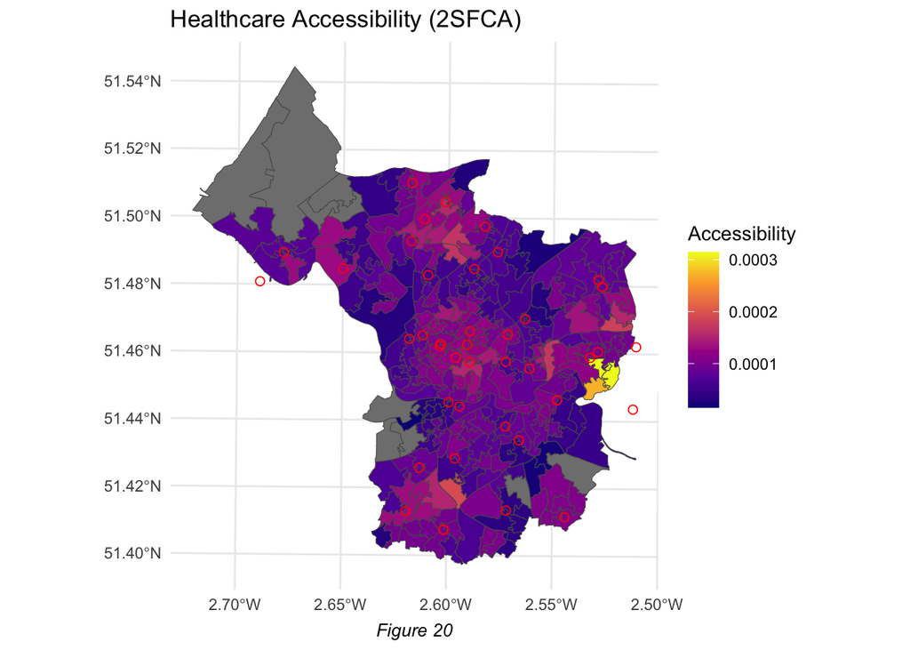

```r
# 2SFCA for walking

# Add population to data

population_2 = read.csv("population.csv")

lsoa_population_2 = merge(lsoa_bristol, population, by.x = "LSOA21CD", by.y = "LSOA.2021.Code")

lsoa_population_2 = lsoa_population_2 %>%
  mutate(Total = gsub(",", "", Total)) %>%
  mutate(Total = as.numeric(Total)) %>%
  mutate(Total = ifelse(is.na(Total), 0, Total))

# Set threshold

threshold = 30 #30 minutes

# Calculate GP-to-population ratios

gp_ratios_2 = dist_walk %>%
  filter(travel_time <= threshold) %>%  # Filter by threshold
  left_join(lsoa_population_2, by = c("from_id" = "LSOA21CD")) %>%  # Join population data
  group_by(to_id) %>%  # Group by GP ID
  summarise(
    catchment_population = sum(Total, na.rm = TRUE),  # Sum population in catchment
    ratio = ifelse(catchment_population == 0, 0, 1 / catchment_population)  # Calculate ratio
  )

#  Calculate accessibility for each LSOA

lsoa_accessibility_2 = dist_walk %>%
  filter(travel_time <= threshold) %>%  # Filter by threshold
  left_join(gp_ratios_2, by = "to_id") %>%  # Join GP ratios
  group_by(from_id) %>%  # Group by LSOA ID
  summarise(
    accessibility = sum(ratio, na.rm = TRUE)  # Sum ratios for each LSOA
  ) %>%
  mutate(accessibility = ifelse(is.na(accessibility), 0, accessibility))  # Replace NA with 0

# Join accessibility scores with LSOA data

lsoa_population_2 = lsoa_population_2 %>%
  left_join(lsoa_accessibility_2, by = c("LSOA21CD" = "from_id"))

# Plot ressults

ggplot(lsoa_population_2) +
  geom_sf(aes(fill = accessibility)) +
    geom_sf(data = gp_bristol, color = "red", size = 2, shape = 21) +
  scale_fill_viridis_c(
    option = "plasma",
    labels = label_number(accuracy = 0.0001)  # Adjust to show 4 decimal places
  ) +
  theme_minimal() +
  labs(title = "Healthcare Accessibility (2SFCA)",
       fill = "Accessibility",
       caption = "Figure 20")+
  theme(
    plot.caption = element_text(size = 10, face = "italic", hjust = 0.5)
  )
```

Figure 20 illustrates 2SFCA scores for GPs/hospital accessibility within a 30-minute walking distance. Results are similar to Figure 19, however, more LSOAs are accessible within 30 minutes of walking compared to 5 minutes of driving. The highest accessibility scores are again seen in the east of Bristol. These areas are likely sparsely populated as they have high accessibility scores in relation to population for both walking and driving. The centre and north of Bristol have consistently mid-range accessibility scores, again highlighting that these areas have a reasonable balance between service availability and population demand. Peripheral north and southeast areas have the lowest scores, likely due to multiple LSOAs sharing one facility. The northwest remains under-served, with no LSOAs within a 30-minute walking distance of any GP or hospital.

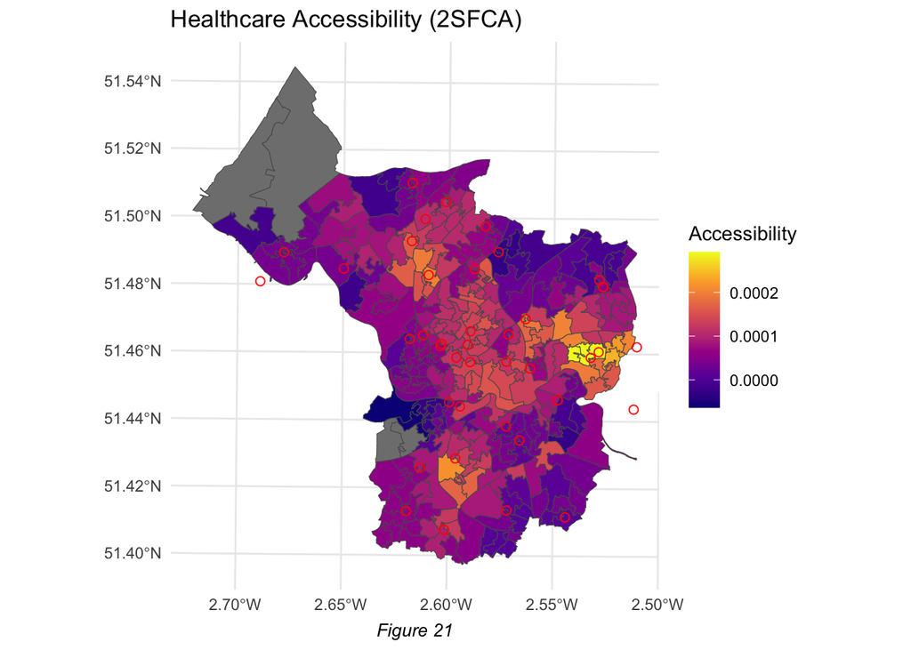

```r
# 2SFCA for cycling

# Adding population to data

population_3 = read.csv("population.csv")

lsoa_population_3 = merge(lsoa_bristol, population_3, by.x = "LSOA21CD", by.y = "LSOA.2021.Code")

lsoa_population_3 = lsoa_population_3 %>%
  mutate(Total = gsub(",", "", Total)) %>%
  mutate(Total = as.numeric(Total)) %>%
  mutate(Total = ifelse(is.na(Total), 0, Total))

# Set threshold

threshold = 15 # 15 minutes

# Calculate GP-to-population ratios

gp_ratios = dist_bike %>%
  filter(travel_time <= threshold) %>%  # Filter by threshold
  left_join(lsoa_population, by = c("from_id" = "LSOA21CD")) %>%  # Join population data
  group_by(to_id) %>%  # Group by GP ID
  summarise(
    catchment_population = sum(Total, na.rm = TRUE),  # Sum population in catchment
    ratio = ifelse(catchment_population == 0, 0, 1 / catchment_population)  # Calculate ratio
  )

#  Calculate accessibility for each LSOA

lsoa_accessibility_3 = dist_bike %>%
  filter(travel_time <= threshold) %>%  # Filter by threshold
  left_join(gp_ratios, by = "to_id") %>%  # Join GP ratios
  group_by(from_id) %>%  # Group by LSOA ID
  summarise(
    accessibility = sum(ratio, na.rm = TRUE)  # Sum ratios for each LSOA
  ) %>%
  mutate(accessibility = ifelse(is.na(accessibility), 0, accessibility))  # Replace NA with 0

# Join accessibility scores with LSOA data

lsoa_population_3 = lsoa_population_3 %>%
  left_join(lsoa_accessibility_3, by = c("LSOA21CD" = "from_id"))

# Plot results

ggplot(lsoa_population_3) +
  geom_sf(aes(fill = accessibility)) +
    geom_sf(data = gp_bristol, color = "red", size = 2, shape = 21) +
  scale_fill_viridis_c(
    option = "plasma",
    labels = label_number(accuracy = 0.0001)  # Adjust to show 4 decimal places
  ) +
  theme_minimal() +
  labs(title = "Healthcare Accessibility (2SFCA)",
       fill = "Accessibility",
       caption = "Figure 21")+
  theme(
    plot.caption = element_text(size = 10, face = "italic", hjust = 0.5)
  )
```

Figure 21 shows 2SFCA scores for accessibility of GPs/hospitals within 15 minutes of cycling. This highlights similar patterns again, with the highest levels of accessibility seen in the east of Bristol. This reinforces the idea that these LSOAs likely have low populations and are sufficiently served by local healthcare infrastructure. The centre and urban areas exhibit mid-range accessibility scores, and periphery areas, particularly in the west exhibit low scores.

## Cluster Analysis

```r
# Combine minimum time data frames to perform additional analysis

lsoa_with_time = lsoa_with_time  %>%
  rename(min_travel_time_car = min_travel_time)

lsoa_with_time_bike = lsoa_with_time_bike  %>%
  rename(min_travel_time_bike = min_travel_time)

lsoa_with_time_walk = lsoa_with_time_walk  %>%
  rename(min_travel_time_walk = min_travel_time)

df = inner_join(lsoa_with_time %>% as.data.frame(), lsoa_with_time_bike %>% as.data.frame(), by = "LSOA21LN")


df = inner_join(df %>% as.data.frame(), lsoa_with_time_walk %>% as.data.frame(), by = "LSOA21LN")

df %<>% st_sf(sf_column_name = 'geometry.x')

lsoa_times = df %>%
  select(-geometry, -geometry.y)
```

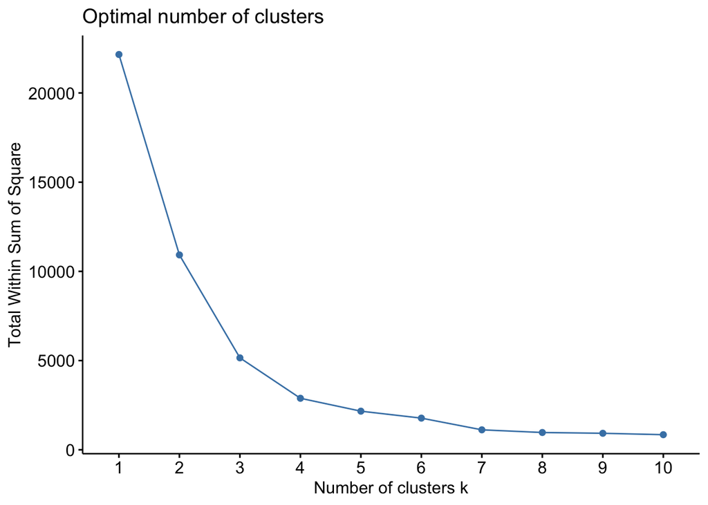

```r
# Define features for clustering

features = st_drop_geometry(lsoa_times[, c("min_travel_time_car", "min_travel_time_bike", "min_travel_time_walk")])

# Finding optimal number of K using the elbow method

fviz_nbclust(
  features,
  kmeans,
  k.max = 10,
  method = "wss"
)
```

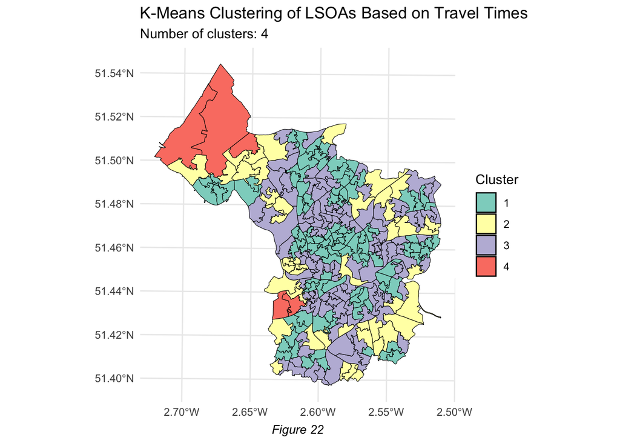

```r
# Set seed for reproducibility

set.seed(123)

# Set k

k = 4

# Calculate k means

kmeans_result = kmeans(features, centers = k, nstart = 25)

# Add cluster labels to the original data

lsoa_times$cluster = as.factor(kmeans_result$cluster)

# Plot results

set.seed(123)
ggplot() +
  geom_sf(data = lsoa_times, aes(fill = cluster), color = "black", size = 0.1) +
  scale_fill_brewer(palette = "Set3", name = "Cluster") +
  theme_minimal() +
  labs(title = "K-Means Clustering of LSOAs Based on Travel Times",
       subtitle = paste("Number of clusters:", k),
       caption = "Figure 22")+
  theme(
    plot.caption = element_text(size = 10, face = "italic", hjust = 0.5)
  )
```

```r
# Interpreting clusters

centroids = kmeans_result$centers

kable(
  centroids,
  caption = "Cluster Centroids: Key Variables",
  col.names = c("min_travel_time_car", "min_travel_time_bike", "min_travel_time_walk"),
  align = "c"
)
```

Cluster Centroids: Key Variables

| min_travel_time_car | min_travel_time_bike | min_travel_time_walk |
| --- | --- | --- |
| 1.632039 | 2.972815 | 7.102913 |
| 4.297826 | 8.254348 | 23.278261 |
| 3.107017 | 5.547368 | 14.070175 |
| 7.020000 | 18.440000 | 54.640000 |

This cluster analysis has returned 4 clusters based on minimum driving, walking and cycling times from each LSOA.

- Cluster 1: Shortest travel times across all modes of transport. These LSOAs are mainly relatively central urban areas that are well-served by health infrastructure.
- Cluster 2: Slightly higher than average travel times across modes of transport. These areas are generally on the outskirts of Bristol suggesting they are moderately connected suburban areas, which are relatively well served by healthcare infrastructure.
- Cluster 3: Average travel times are relatively short across all modes of transport. These areas are generally suburban areas, which are well-connected and well-served by healthcare infrastructure.
- Cluster 4: Highest average travel times for all modes of transport, with particularly long transport times for biking and walking. These LSOAs are situated in the outskirts of the northwest and southwest of Bristol. Significant travel times for these LSOAs suggest that these areas would have to be more car-dependent and are under-served by healthcare infrastructure.

## Equity Assessment

### IMD and HDD

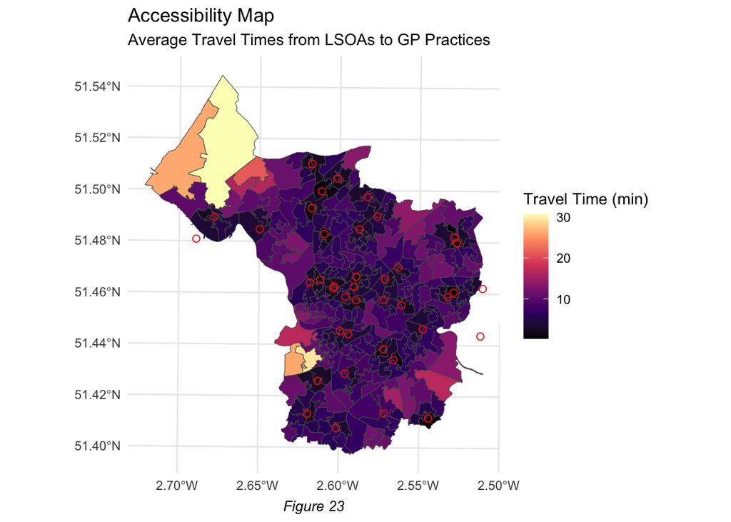

```r
# Convert to a regular data frame, dropping the geometry column

lsoa_times_no_geometry = sf::st_drop_geometry(lsoa_times)

# Add average travel time column

lsoa_times_no_geometry$average_travel_time = rowMeans(
  lsoa_times_no_geometry[, c("min_travel_time_car", "min_travel_time_bike", "min_travel_time_walk")],
  na.rm = TRUE
)

# Add the geometry back to the data frame
lsoa_times_with_means = cbind(lsoa_times_no_geometry, geometry = sf::st_geometry(lsoa_times))

# Convert back to an sf object
lsoa_times = sf::st_as_sf(lsoa_times_with_means)

# Plot average times

plot1 = ggplot() +
  geom_sf(data = lsoa_times, aes(fill = average_travel_time)) +
  geom_sf(data = gp_bristol, color = "red", size = 2, shape = 21) +
  scale_fill_viridis_c(option = "magma", name = "Travel Time (min)") +
  labs(
    title = "Accessibility Map",
    subtitle = "Average Travel Times from LSOAs to GP Practices",
    caption = "Figure 23"
  ) +
  theme_minimal()+
  theme(
    plot.caption = element_text(size = 10, face = "italic", hjust = 0.5)

  )

plot1
```

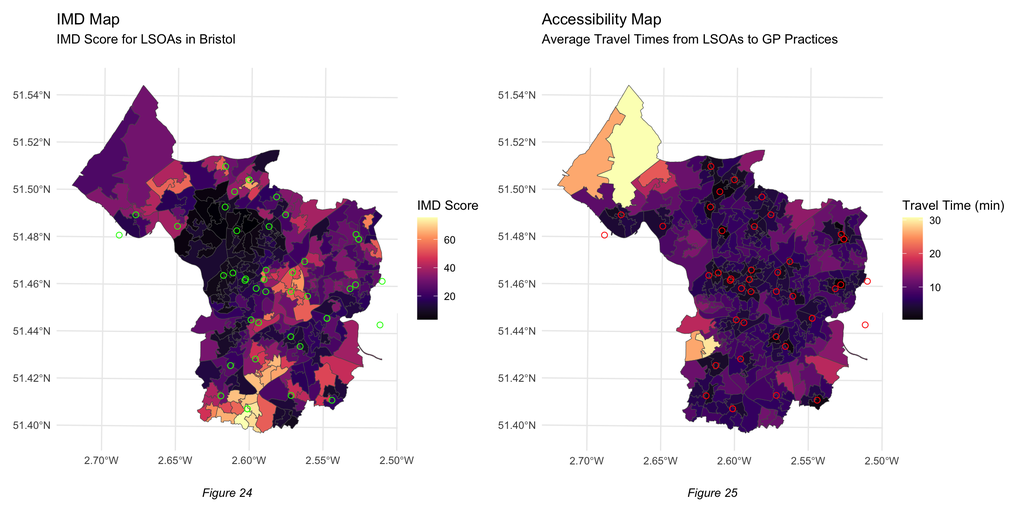

```r
# IMD data

IMD = read_sf("Deprivation_in_Bristol_2019_(LSOA11).shp")

# Plot IMD

imd_plot = ggplot() +
  geom_sf(data = IMD, aes(fill = IMDSCORE)) +
  scale_fill_viridis_c(option = "magma", name = "IMD Score") +
  geom_sf(data = gp_bristol, color = "green", size = 2, shape = 21) +
  labs(
    title = "IMD Map",
    subtitle = "IMD Score for LSOAs in Bristol",
    caption = "Figure 24"
  ) +
  theme_minimal()+
  theme(
    plot.caption = element_text(size = 10, face = "italic", hjust = 0.5)
  )

# Plot average for comparison

average_plot = ggplot() +
  geom_sf(data = lsoa_times, aes(fill = average_travel_time)) +
  geom_sf(data = gp_bristol, color = "red", size = 2, shape = 21) +
  scale_fill_viridis_c(option = "magma", name = "Travel Time (min)") +
  labs(
    title = "Accessibility Map",
    subtitle = "Average Travel Times from LSOAs to GP Practices",
    caption = "Figure 25"
  ) +
  theme_minimal()+
  theme(
    plot.caption = element_text(size = 10, face = "italic", hjust = 0.5)
  )

combined_plot = imd_plot + average_plot +
  plot_layout(ncol = 2, widths = c(1, 1))

combined_plot
```

There is no clear correlation between IMD and average travel times, however, generally, there seems to be a negative correlation, suggesting that more deprived areas have better access to healthcare. This is clear in the south of Bristol, where IMD scores are particularly high (high deprivation levels) and average travel time to GPs/Hospitals is relatively low. This pattern is also seen in central areas of Bristol. This may be due to more urban, densely populated areas having better access to healthcare facilities. Some periphery areas, such as the southwest, northeast and northwest, exhibit relatively high IMD scores and high travel times, suggesting that IMD may impact healthcare access in more rural areas, however, this pattern is tenuous.

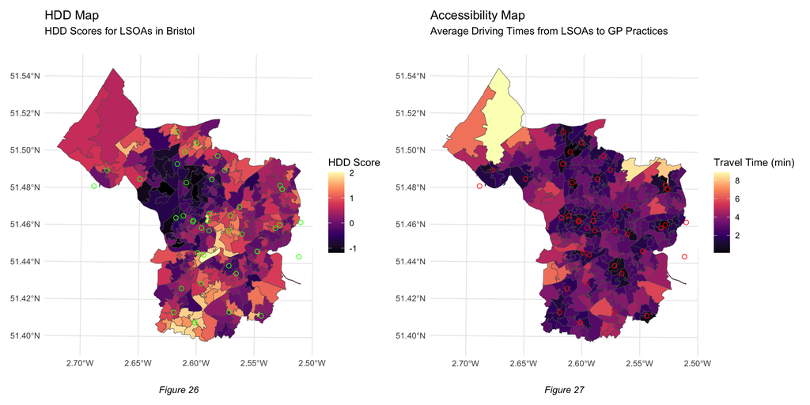

```r
#Plot HDD

HDD_plot = ggplot() +
  geom_sf(data = IMD, aes(fill = HDDSCORE)) +
  scale_fill_viridis_c(option = "magma", name = "HDD Score") +
  geom_sf(data = gp_bristol, color = "green", size = 2, shape = 21)+
  labs(
    title = "HDD Map",
    subtitle = "HDD Scores for LSOAs in Bristol",
    caption = "Figure 26"
  ) +
  theme_minimal()+
  theme(
    plot.caption = element_text(size = 10, face = "italic", hjust = 0.5)
  )

# Plot average for comparison

average_plot = ggplot() +
  geom_sf(data = lsoa_times, aes(fill = min_travel_time_car)) +
  geom_sf(data = gp_bristol, color = "red", size = 2, shape = 21) +
  scale_fill_viridis_c(option = "magma", name = "Travel Time (min)") +
  labs(
    title = "Accessibility Map",
    subtitle = "Average Driving Times from LSOAs to GP Practices",
    caption = "Figure 27"
  ) +
  theme_minimal()+
  theme(
    plot.caption = element_text(size = 10, face = "italic", hjust = 0.5)
  )

combined_plot = HDD_plot + average_plot +
  plot_layout(ncol = 2, widths = c(1, 1))

combined_plot
```

Healthcare Domain Deprivation (HDD), is a specific component of IMD that measures deprivation related to health outcomes and disability. Again there is no clear visual pattern between HDD and average travel times, however, there are hotspots of correlation. The areas with the highest average travel times in the northwest and southwest of Bristol both exhibit relatively high HDD scores, indicating that these areas are under-served in terms of healthcare infrastructure, potentially impacting health outcomes. Areas such as the city centre and south of Bristol have high HDD scores, which do not correlate to higher travel times, implying that these areas face non-spatial barriers that affect HDD.

### Ethnicity

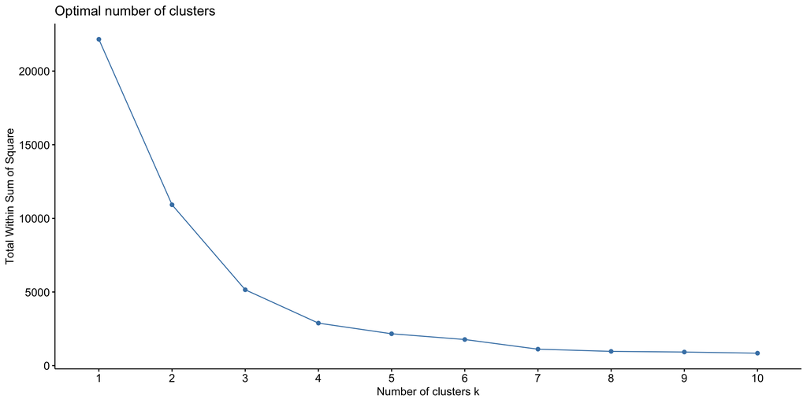

```r
# Download ethnicity data

ethnicity = read.csv("ethnicity.csv")

# Merge

ethnicity_lsoa = merge(lsoa_bristol, ethnicity, by.x = "LSOA21CD", by.y = "Lower.layer.Super.Output.Areas.Code")

# Work out ethnicity percentages of populations

ethnicity_lsoa = ethnicity_lsoa %>%
  group_by(`LSOA21CD`) %>%
  mutate(Total_Population = sum(Observation, na.rm = TRUE)) %>%
  ungroup()

ethnicity_lsoa = ethnicity_lsoa %>%
  mutate(Percentage = (Observation / Total_Population) * 100)

ethnicity_tidy = ethnicity_lsoa %>%
  select(`LSOA21CD`, `Ethnic.group..20.categories.`, Percentage)

wide_data = ethnicity_tidy %>%
  pivot_wider(
    names_from = `Ethnic.group..20.categories.`,
    values_from = Percentage
  )

# Define features for clustering

features_2 = st_drop_geometry(wide_data[, c("White: Gypsy or Irish Traveller", "White: Other White", "Other ethnic group: Any other ethnic group", "Asian, Asian British or Asian Welsh: Bangladeshi", "Black, Black British, Black Welsh, Caribbean or African: Other Black", "Mixed or Multiple ethnic groups: Other Mixed or Multiple ethnic groups", "Asian, Asian British or Asian Welsh: Other Asian","Asian, Asian British or Asian Welsh: Chinese", "Other ethnic group: Arab", "Asian, Asian British or Asian Welsh: Indian", "White: English, Welsh, Scottish, Northern Irish or British", "Black, Black British, Black Welsh, Caribbean or African: African", "Black, Black British, Black Welsh, Caribbean or African: Caribbean", "Mixed or Multiple ethnic groups: White and Black African", "Asian, Asian British or Asian Welsh: Pakistani", "White: Irish", "Mixed or Multiple ethnic groups: White and Asian", "Mixed or Multiple ethnic groups: White and Black Caribbean","White: Roma" )])

# Finding optimal number of K using the elbow method

fviz_nbclust(
  features,
  kmeans,
  k.max = 10,
  method = "wss"
)
```

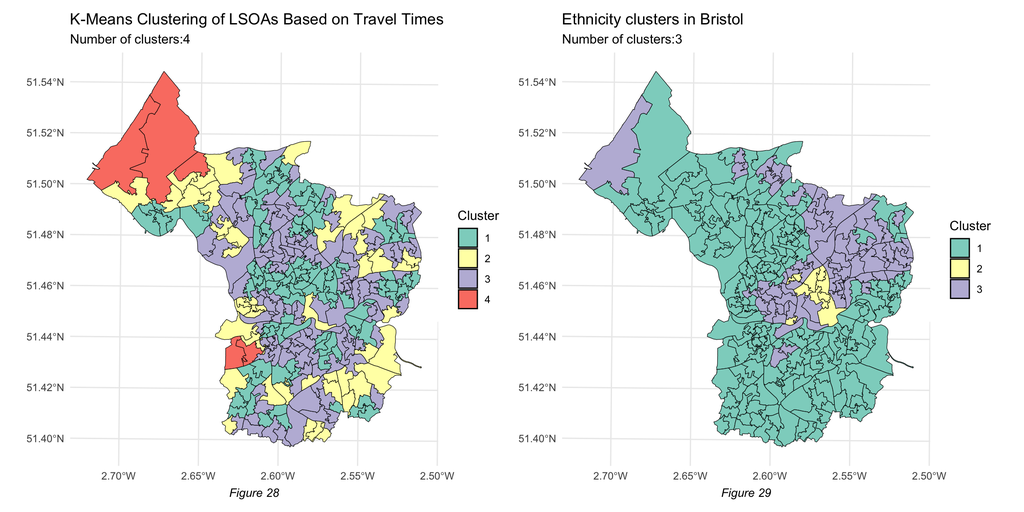

```r
# Set seed for reproducibility

set.seed(123)

# Set k

k = 3

# Calculate kmeans

kmeans_result_2 = kmeans(features_2, centers = k, nstart = 25)

# Add cluster labels to the original data

wide_data$cluster = as.factor(kmeans_result_2$cluster)

# Plot

new = ggplot() +
  geom_sf(data = wide_data, aes(fill = cluster), color = "black", size = 0.1) +
  scale_fill_brewer(palette = "Set3", name = "Cluster") +
  theme_minimal() +
  labs(title = "Ethnicity clusters in Bristol",
       subtitle = "Number of clusters:3",
       caption = "Figure 29")+ theme(
    plot.caption = element_text(size = 10, face = "italic", hjust = 0.5)
  )

# Plot travel time clusters for comparison

original = ggplot() +
  geom_sf(data = lsoa_times, aes(fill = cluster), color = "black", size = 0.1) +
  scale_fill_brewer(palette = "Set3", name = "Cluster") +
  theme_minimal() +
  labs(title = "K-Means Clustering of LSOAs Based on Travel Times",
       subtitle = "Number of clusters:4",
       caption = "Figure 28")+
  theme(
    plot.caption = element_text(size = 10, face = "italic", hjust = 0.5)
  )

original + new
```

```r
# Interpret clusters

centroids_2 = kmeans_result_2$centers

kable(
  centroids_2,
  caption = "Cluster Centroids: Key Variables",
  col.names = c("White: Gypsy or Irish Traveller", "White: Other White", "Other ethnic group: Any other ethnic group", "Asian, Asian British or Asian Welsh: Bangladeshi", "Black, Black British, Black Welsh, Caribbean or African: Other Black", "Mixed or Multiple ethnic groups: Other Mixed or Multiple ethnic groups", "Asian, Asian British or Asian Welsh: Other Asian","Asian, Asian British or Asian Welsh: Chinese", "Other ethnic group: Arab", "Asian, Asian British or Asian Welsh: Indian", "White: English, Welsh, Scottish, Northern Irish or British", "Black, Black British, Black Welsh, Caribbean or African: African", "Black, Black British, Black Welsh, Caribbean or African: Caribbean", "Mixed or Multiple ethnic groups: White and Black African", "Asian, Asian British or Asian Welsh: Pakistani", "White: Irish", "Mixed or Multiple ethnic groups: White and Asian", "Mixed or Multiple ethnic groups: White and Black Caribbean","White: Roma"),
  align = "c"
)
```

Cluster Centroids: Key Variables

| White: Gypsy or Irish Traveller | White: Other White | Other ethnic group: Any other ethnic group | Asian, Asian British or Asian Welsh: Bangladeshi | Black, Black British, Black Welsh, Caribbean or African: Other Black | Mixed or Multiple ethnic groups: Other Mixed or Multiple ethnic groups | Asian, Asian British or Asian Welsh: Other Asian | Asian, Asian British or Asian Welsh: Chinese | Other ethnic group: Arab | Asian, Asian British or Asian Welsh: Indian | White: English, Welsh, Scottish, Northern Irish or British | Black, Black British, Black Welsh, Caribbean or African: African | Black, Black British, Black Welsh, Caribbean or African: Caribbean | Mixed or Multiple ethnic groups: White and Black African | Asian, Asian British or Asian Welsh: Pakistani | White: Irish | Mixed or Multiple ethnic groups: White and Asian | Mixed or Multiple ethnic groups: White and Black Caribbean | White: Roma |
| --- | --- | --- | --- | --- | --- | --- | --- | --- | --- | --- | --- | --- | --- | --- | --- | --- | --- | --- |
| 0.0547159 | 7.266437 | 0.9147714 | 0.2598899 | 0.2894187 | 0.8988224 | 0.9394546 | 0.7725893 | 0.3032835 | 1.167226 | 80.13972 | 1.527879 | 0.6832585 | 0.4512381 | 0.8426981 | 0.9448487 | 1.1146146 | 1.299431 | 0.1297033 |
| 0.1218283 | 8.928539 | 3.7424645 | 1.6083938 | 3.2567105 | 1.5452001 | 1.6205587 | 0.6764299 | 1.3777152 | 1.670664 | 29.52998 | 29.821783 | 5.1655445 | 1.0691102 | 5.1310247 | 0.7341823 | 0.8075915 | 2.866556 | 0.3257218 |
| 0.0558845 | 10.630117 | 2.1148394 | 1.0409206 | 0.9894387 | 1.4900327 | 1.8630699 | 2.2094641 | 0.9956600 | 3.135611 | 58.52573 | 5.294527 | 2.5272463 | 0.6817686 | 3.7510753 | 0.8410003 | 1.3272253 | 2.179181 | 0.3472029 |

In this analysis, cluster 1 represents predominantly white British areas, cluster 2 represents a significantly ethnically diverse area and cluster 3 represents a moderately ethnically diverse area. There are limited correlations between travel time clusters and ethnicity clusters, however, we can see a slight correlation between more ethnically diverse areas and faster travel times. This is likely due to more diverse populations in densely populated urban centres.

### Car Ownership

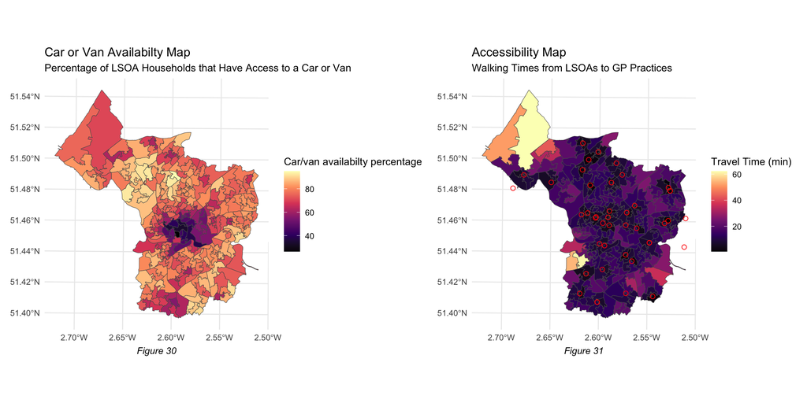

```r
# Download car ownership data

car_ownership = read.csv("car availabilty.csv")

# Merge

car_ownership_lsoa = merge(lsoa_bristol, car_ownership, by.x = "LSOA21CD", by.y = "Lower.layer.Super.Output.Areas.Code")

# Work out percentage of LSOAs that have access to a car/van

car_ownership_lsoa = car_ownership_lsoa %>%
  group_by(`LSOA21CD`) %>%
  mutate(Total_Population = sum(Observation, na.rm = TRUE)) %>%
  ungroup()

car_ownership_lsoa = car_ownership_lsoa %>%
  mutate(Percentage = (Observation / Total_Population) * 100)

car_ownership_lsoa = car_ownership_lsoa %>%
  select(`LSOA21CD`, `Car.or.van.availability..5.categories.`, Percentage)

wide_data = car_ownership_lsoa %>%
  pivot_wider(
    names_from = `Car.or.van.availability..5.categories.`,
    values_from = Percentage
  )

wide_data$total_availability = wide_data$`1 car or van in household` + wide_data$`2 cars or vans in household` + wide_data$`3 or more cars or vans in household`

# Plot results

car_availability = ggplot() +
  geom_sf(data = wide_data, aes(fill = total_availability)) +
  scale_fill_viridis_c(option = "magma", name = "Car/van availabilty percentage") +
  labs(
    title = "Car or Van Availabilty Map",
    subtitle = "Percentage of LSOA Households that Have Access to a Car or Van",
    caption = "Figure 30"
  ) +
  theme_minimal()+
  theme(
    plot.caption = element_text(size = 10, face = "italic", hjust = 0.5)
  )

# Plot walking times for comparison

car_access = ggplot() +
  geom_sf(data = lsoa_times, aes(fill = min_travel_time_walk)) +
  geom_sf(data = gp_bristol, color = "red", size = 2, shape = 21) +
  scale_fill_viridis_c(option = "magma", name = "Travel Time (min)") +
  labs(
    title = "Accessibility Map",
    subtitle = "Walking Times from LSOAs to GP Practices",
    caption = "Figure 31"
  ) +
  theme_minimal()+
  theme(
    plot.caption = element_text(size = 10, face = "italic", hjust = 0.5)
  )

car_availability + car_access
```

Figure 30 shows the percentage of households within each LSOA with access to a car or van. The availability is highest in peripheral and suburban areas and lowest in the centre of Bristol. In terms of accessibility, this means that residents of areas that have high walking times, mostly in peripheral areas, particularly in the northwest and southwest of Bristol, have a higher likelihood of having access to a car, meaning GPs or hospitals would remain accessible. However, this does promote a reliance on driving.

## Statistical Analysis

```r
# Simplifying data for ease of merge + merging variables

IMD_simple = IMD[, c("LSOA11CD", "LSOA11NM", "IMDSCORE", "HDDSCORE")]

IMD_simple_df =  st_drop_geometry(IMD_simple)

IMD_time = merge(IMD_simple_df, lsoa_times_no_geometry, by.x = "LSOA11NM", by.y = "LSOA21LN")

Population_simple = lsoa_population[, c("LSOA21CD", "LSOA21LN", "Total")]

Population_simple_df = st_drop_geometry(Population_simple)

IMD_time_pop = merge(IMD_time, Population_simple_df, by.x = "LSOA11NM", by.y = "LSOA21LN")

# Calculating correlations

# Correlation with IMD

IMD_correlation = cor(IMD_time$IMDSCORE, IMD_time$average_travel_time, method = "pearson")
print(IMD_correlation)
```

```
## [1] -0.01415345
```

```r
# Correlation with HDD

HDD_correlation= cor(IMD_time$HDDSCORE, IMD_time$average_travel_time, method = "pearson")
print(HDD_correlation)
```

```
## [1] -0.03228079
```

```r
# Correlation with population

population_correlation = cor(IMD_time_pop$Total, IMD_time_pop$average_travel_time, method = "pearson")
print(population_correlation )
```

```
## [1] -0.02259429
```

```r
# Linear regression model

model = lm(average_travel_time ~ Total + IMDSCORE + HDDSCORE, data = IMD_time_pop)

# View the summary of the model
summary(model)
```

```
##
## Call:
## lm(formula = average_travel_time ~ Total + IMDSCORE + HDDSCORE,
##     data = IMD_time_pop)
##
## Residuals:
##     Min      1Q  Median      3Q     Max
## -7.1124 -2.6540 -0.5352  1.4794 23.4085
##
## Coefficients:
##               Estimate Std. Error t value Pr(>|t|)
## (Intercept)  7.5932192  1.5435835   4.919 1.56e-06 ***
## Total       -0.0003829  0.0008313  -0.461    0.645
## IMDSCORE     0.0233294  0.0371317   0.628    0.530
## HDDSCORE    -0.6774034  0.8608200  -0.787    0.432
## ---
## Signif. codes:  0 '***' 0.001 '**' 0.01 '*' 0.05 '.' 0.1 ' ' 1
##
## Residual standard error: 4.219 on 256 degrees of freedom
## Multiple R-squared:  0.003071,   Adjusted R-squared:  -0.008611
## F-statistic: 0.2629 on 3 and 256 DF,  p-value: 0.8521
```

## Discussion

**RQ1: What are the spatial patterns of travel times from Lower Super Output Areas (LSOAs) in Bristol to the nearest GP surgery or hospital, and how do these vary across the city?**

The general spatial patterns highlighted throughout this study are that central and urban areas are the most well-served by healthcare infrastructure with the lowest travel times in all modes of transport and periphery areas have fewer healthcare services and higher travel times. This is consistent with observed patterns in the UK, with more rural areas suffering from higher travel times to health infrastructure (Glick, 2020).

This analysis has identified several hotspots of LSOAs that are under-served, including Kingweston Avenue, which has the highest travel times for all modes of transport, Lawrence Weston East and Avonmouth Docks which are in the top five travel times for all modes of transport and Ashton Vale and Windermere Road which are in the top five travel times for walking and cycling. These areas face significant physical barriers to health care and should be prioritised in future health-policy making. However it should be noted that Kingweston Avenue contains a significant amount of unpopulated land and Avonmouth Docks is a primarily industrial area, this therefore may reduce the demand for healthcare in these LSOAs. Despite this the populations of these LSOAs are 1637 and 1965 respectively, so demand does exist.

Walking times exhibit the greatest range (under a minute to over an hour), indicating a wide disparity in accessibility for pedestrians, cycling exhibits a moderate range (under a minute to 21 minutes) and driving times are the least variable (under a minute to 8.9 minutes). Driving provides the most efficient access, particularly for peripheral areas that have long walking and driving times, promoting a reliance on vehicles outside of the central areas of Bristol. This is problematic as a third of the city’s direct emissions come from transport (Bristol City Council, 2024), however, the West of England Combined Authority is investing over £400m in a cycling and walking infrastructure plan that will provide high-quality infrastructure to ensure cycling and walking are the preferred choice for shorter trips (WOECA, 2024).

**RQ2: How do demographic and socioeconomic factors influence accessibility to GPs and hospitals within Bristol?**

The analysis found no statistical correlation between accessibility to GPs and hospitals and demographic or socioeconomic factors such as the Index of Multiple Deprivation (IMD), Healthcare Domain Deprivation (HDD), or population size. However from a visual analysis hotspots of correlation were identified.

For HDD, average travel times in the northwest and southwest of Bristol both exhibited relatively high HDD scores, indicating that these areas are under-served in terms of healthcare infrastructure and the city centre and south of Bristol have high HDD scores, which do not correlate with higher travel times, implying that these areas face non-spatial barriers to healthcare.

Contrary to literature regarding healthcare access in the UK (Chouhan & Nazroo, 2020), this study found no significant correlations between diversity and access to healthcare. The only tenuous correlation uncovered was a positive correlation between diversity and access found in the city centre. This correlation however, would most likely be driven by the density of healthcare infrastructure rather than a direct demographic effect.

Car ownership emerged as a useful variable for analysing accessibility in LSOAs with high walking and cycling times. High car ownership in these areas often compensates for limited accessibility by foot or bike, improving overall access to healthcare services.

## Limitations

There are several limitations to this study including:

**The use of the OSRM package to calculate driving, walking and cycling times:**

This is a limitation as these calculations often underestimate travel time in urban areas due to not taking into account traffic congestion or time of day and for walking and cycling elevation is not considered.

**The use of centroids to calculate accessibility measures:**

This is a limitation as centroids are a simplification that does not accurately reflect the geography of LSOAs or the individuals that live within them. There is potential for populations to cluster in other areas of the LSOA, meaning accessibility measures and travel times may not accurately describe real-life patterns.

**Lack of consideration of additional factors :**

This study lacks consideration of public transport and additional socioeconomic factors such as employment or income which could impact healthcare accessibility and demand. In addition, the focus on physical distances and travel times does not account for non-spatial barriers to healthcare services.

**Subjective thresholds:**

Setting subjective thresholds introduces potential bias as these thresholds may not accurately capture the diverse experiences and needs of different populations.

## Conclusion

In conclusion, this study highlights the complexities and challenges of healthcare accessibility within Bristol. With physical barriers to accessibility mainly concentrated in periphery areas and select LSOAs, future policy should aim to address these disparities by enhancing healthcare infrastructure. This study lacked the discovery of strenuous correlations between healthcare access and socio-demographic variables, however, potential patterns emerged and therefore this should be a focus for future research.

## Bibliography

Bristol City Council (2024) Our climate action on transport. Available at: https://www.bristol.gov.uk/council/policies-plans-and-strategies/our-action-on-climate-and-ecology/our-climate-action-on-transport (Accessed: 28/11/2024)

Cowling, D. (2014) “Inequalities in health care provision” Teaching Geography, 39(2), pp. 1-4

Chouhan, K & Nazroo, J (2020) “Health inequalities” in Byrne, B., Alexander, C., Khan, O., Nazro, J., Shankley, W’s (ed). Ethnicity and Race in the UK: State of the Nation, Bristol: Bristol University Press, pp. 73-92

Glick, R (2020) The UK National Health Service: A Rural Versus Urban Perspective Available at: https://sma.org/the-uk-national-health-service/ (Accessed: 28/11/2024)

Goddard, M & Smith, P (2001) “Equity of access to health care services:: Theory and evidence from the UK”, Social Science and Medicine, 53(9), pp. 1149-1162

Goldbeck, J (2013) Analyzing the Social Web. Massachusetts: Morgan Kaufmann

Goldbeck, J (2015) Introduction to Social Media Investigation. Amsterdam: Elsevier Science

Healthwatch (2024) “Investigating Local Health Inequalities Using the Core20PLUS5 Approach” Available at:https://www.healthwatchbristol.co.uk/sites/healthwatchbristol.co.uk/files/Investigating Local Health Inequalities using the CORE20PLUS5 approach April 2024 FINAL_1.pdf (Accessed: 13/11/2024)

Liu, L., Lyu, H., Zhao, Y., Zhou, D (2022) “An Improved Two-Step Floating Catchment Area (2SFCA) Method for Measuring Spatial Accessibility to Elderly Care Facilities in Xi’an, China” International Journal of Environmental Research and Public Health, 19(18)

Mallorie, S (2024) “Illustrating the relationship between poverty and NHS services” Available at: https://www.kingsfund.org.uk/insight-and-analysis/long-reads/relationship-poverty-nhs-services#:~:text=Greater illness and less access,double that of the highest. (Accessed: 13/11/2024)

NHS (2024) What are healthcare inequalities? Available at: https://www.england.nhs.uk/about/equality/equality-hub/national-healthcare-inequalities-improvement-programme/what-are-healthcare-inequalities/ (Accessed: 13/11/2024)

Wasserman, S & Faust, K (1994) Social Network Analysis, Methods and Applications. Cambridge: Cambridge University Press

West of England Combined Authority (2024) Local Cycling and Walking Infrastructure Plan. Available at: https://www.westofengland-ca.gov.uk/what-we-do/transport/local-cycling-and-walking-infrastructure-plan/ (Accessed: 28/11/2024)

WHO (2023) Human rights Available at: https://www.who.int/news-room/fact-sheets/detail/human-rights-and-health (Accessed: 13/11/2024)